# Exam_3

Lacee Bowen

11/28/2020

### College faculty salaries and total compensation records from 1995 are shown below. The salaries were based on rank, tier, and state.

##### There are three ranks: Assistant (not tenured), Associate (tenured), and Full (exceeding tenure).

##### The tiers refer to the amount of funding devoted to research vs the amount of funding for teaching, with Tier I being universities that spend more on research than teaching and award PhD degrees.

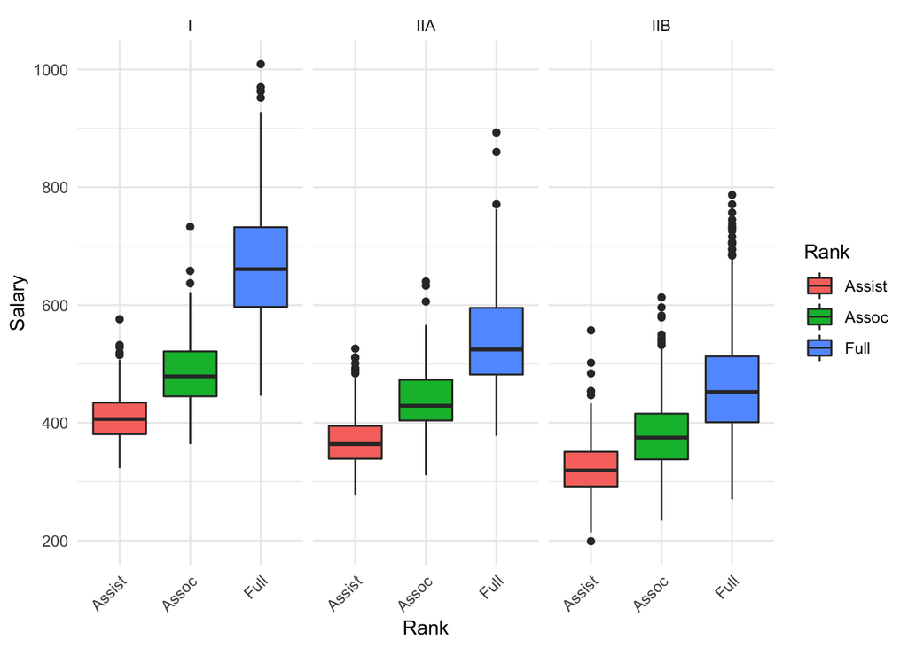

```r
##Task I, recreating fig1.png
# renaming the text for the x axis
FacultySalaries_1995 <- FacultySalaries_1995 %>%
  rename(Full = AvgFullProfSalary, Assoc = AvgAssocProfSalary, Assist = AvgAssistProfSalary)

# creating one column which all of the following are in
combine_columns <- c("Full","Assoc","Assist")
FacultySalaries_1995_long <- pivot_longer(FacultySalaries_1995, cols = combine_columns,
                                          names_to = "Rank",
                        values_to = "Salary", names_prefix = "Avg")

#getting rid of VIIB
without_VIIB <- FacultySalaries_1995_long[-c(3463:3465), ]

# the facet wrapped graph
p1 <- ggplot(without_VIIB, aes(x=Rank, y=Salary, fill = Rank))+
  geom_boxplot()+
  labs(x = "Rank")+
  facet_wrap(~Tier)+
  theme_minimal()+
  theme(axis.text.x = element_text(angle = 45, hjust = 1))
p1
```

```r
ggsave(filename = "BOWEN_Fig_1.jpg", p1)
```

###### Fig 1 shows relative salary based on rank for three separate teirs. Generally, those who have been around for longer have higher salaries. Those at universities where more money is spent on research than teaching tend to make more money as well.

#### Table 1 below shows the influence of state, tier, and rank on Salary:

```r
## Task II Anova test
# below are three models testing the influence of state, tier, and rank on salary
Anova <- aov(Salary ~ State + Tier + Rank, data = FacultySalaries_1995_long)
Anova_summary <- summary(Anova)
Anova_summary
```

```
##               Df   Sum Sq Mean Sq F value Pr(>F)
## State         51  5682396  111420   30.66 <2e-16 ***
## Tier           2  7072361 3536180  972.96 <2e-16 ***
## Rank           2 16529771 8264885 2274.04 <2e-16 ***
## Residuals   3299 11990072    3634
## ---
## Signif. codes:  0 '***' 0.001 '**' 0.01 '*' 0.05 '.' 0.1 ' ' 1
## 128 observations deleted due to missingness
```

```r
capture.output(Anova_summary, file = "./Salary_ANOVA_Summary.txt")
```

```r
## Task III cleaning Juniper Oils data using pivot_longer
combine_columns2 <- c("alpha-pinene","para-cymene","alpha-terpineol","cedr-9-ene","alpha-cedrene","beta-cedrene","cis-thujopsene","alpha-himachalene","beta-chamigrene","cuparene","compound 1","alpha-chamigrene","widdrol","cedrol","beta-acorenol","alpha-acorenol","gamma-eudesmol","beta-eudesmol","alpha-eudesmol","cedr-8-en-13-ol","cedr-8-en-15-ol","compound 2","thujopsenal")
Juniper_Oils_long <- pivot_longer(Juniper_Oils, combine_columns2, names_to = "Chemicals", values_to = "Concentration")
```

### Dead cedar trees were collected and the chemical composition of their essential oil content was measured. The hypothesis was that certain chemicals would degrade over time since they died in fires.

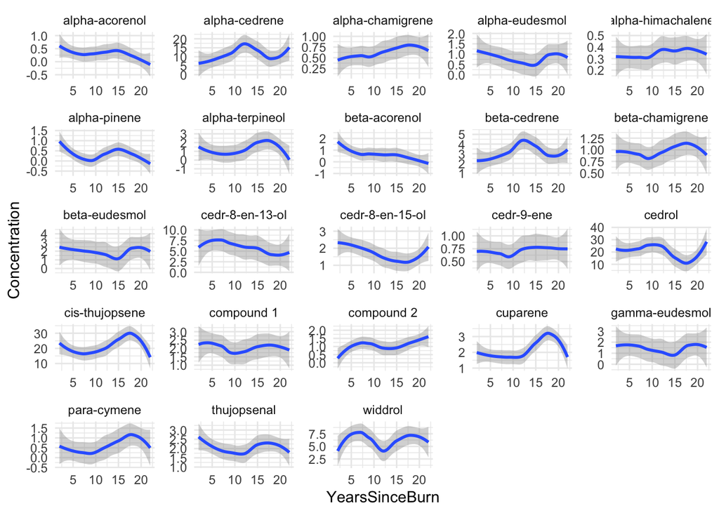

```r
## Task IV duplicating fig2.png
p2 <- ggplot(Juniper_Oils_long, aes(x= YearsSinceBurn, y= Concentration))+
  geom_smooth()+
  facet_wrap(~Chemicals, scales = "free")+
  theme_minimal()
p2
```

```r
ggsave(filename = "BOWEN_Fig_2.jpg", p2)
```

###### Fig 2 shows concentration of essential oil content based on the amount of years since the burn.

```r
## Task V
# below is a model for which chemicals show concentrations that are significantly (significant, as in P < 0.05) affected by "Years Since Burn"
mod4 <- glm(data = Juniper_Oils_long, formula = Concentration ~ YearsSinceBurn + Chemicals)
summary(mod4)
# below is a new data frame from mod4
tidy(mod4)
# get variables with p value less than 0.05
mod4_significant <- tidy(mod4)
mod4_significant
filter(mod4_significant, p.value < 0.05)
# this is the data frame only showing chemicals with significant p values
sig_pvalue <- filter(mod4_significant, p.value < 0.05)
```

[output not shown]

```r
sig_pvalue
```

```
## # A tibble: 10 x 5
##    term                     estimate std.error statistic  p.value
##    <chr>                       <dbl>     <dbl>     <dbl>    <dbl>
##  1 Chemicalsalpha-cedrene      10.6      0.899     11.8  1.13e-29
##  2 Chemicalsbeta-cedrene        2.78     0.899      3.09 2.09e- 3
##  3 Chemicalsbeta-eudesmol       1.79     0.899      1.99 4.71e- 2
##  4 Chemicalscedr-8-en-13-ol     5.55     0.899      6.17 1.08e- 9
##  5 Chemicalscedrol             19.8      0.899     22.0  1.40e-83
##  6 Chemicalscis-thujopsene     21.3      0.899     23.7  3.09e-93
##  7 Chemicalscompound 1          1.82     0.899      2.02 4.36e- 2
##  8 Chemicalscuparene            1.92     0.899      2.14 3.28e- 2
##  9 Chemicalsthujopsenal         1.79     0.899      1.99 4.71e- 2
## 10 Chemicalswiddrol             6.14     0.899      6.82 1.84e-11
```